# Features That Increased The Chances of Getting a Loan

## by: David Akuffo-Boateng

## Investigation Overview

> In this investigation, I looked at features that increased the chances of getting a loan. I focused primarily on the following variables; ProsperRating (Alpha), LoanOriginalAmount, DebtToIncomeRatio, IncomeRange, MonthlyLoanPayment, StatedMonthlyIncome, LoanOriginationDate, EmploymentStatus, IsBorrowerHomeowner, IncomeVerifiable, Term and ListingCategory.

## Dataset Overview

> Prosper Loans is a Carlifornia-based peer-to-peer lending platform, where individuals can either invest in personal loans or request to borrow money. The dataset consisted of 113,937 loans with 81 variables. I investigated the features that increased the chances of getting a loan. Since management of Prosper started to introduce some variables from July 2009, it was prudent to filter our features of interest from July 1, 2009. This will do away with bias and give us more accurate insights from our features of interest.

## ProsperRating (Alpha) by EmploymentStatus

> Borrowers who were employed were the majority of people who went in for loans, and most of these had an appreciable prosper rating, with C-rating having the largest borrowers.

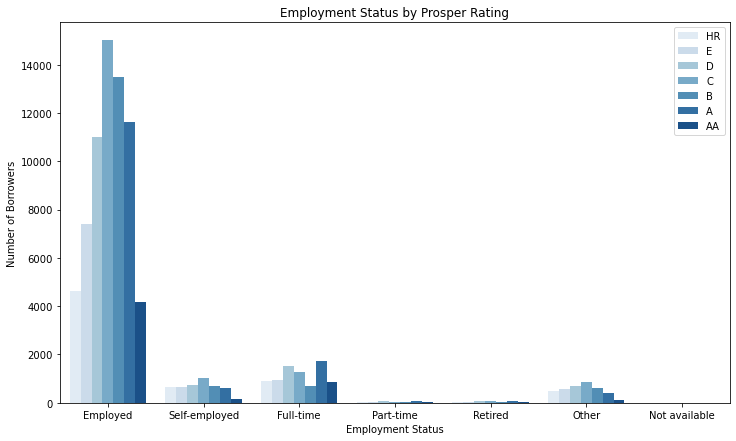

## ProsperRating (Alpha) by StatedMonthlyIncome

> There's a trend of borrowers' monthly incomes increasing as the ratings gets higher. Thus, the larger a borrower's monthly income, the higher the prosper rating and chance of getting a loan.

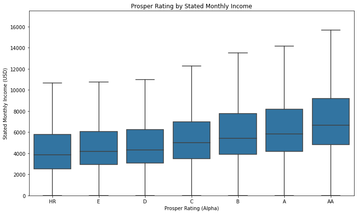

## ProsperRating (Alpha) by EmploymentStatus and StatedMonthlyIncome

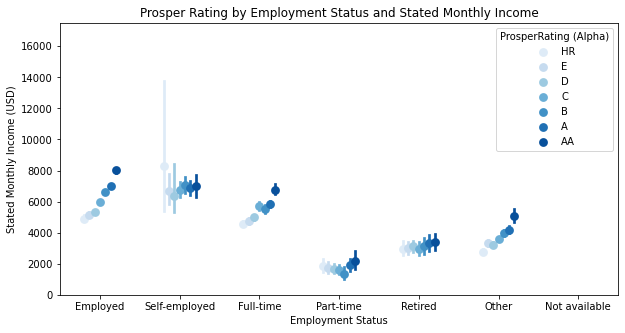

## ProsperRating by DebtToIncomeRatio

> It is clearly indicated that as the ratings gets higher, the debt to income ratio gets lower; meaning borrowers who had low debt to income ratio had the better chance of getting a loan, as there's a less risk of giving out loans to such borrowers.

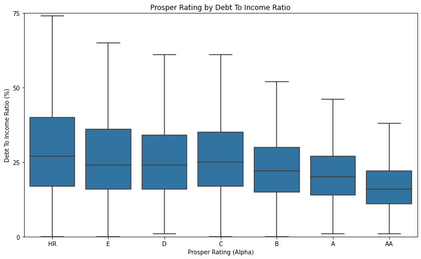

## ProsperRating by DebtToIncomeRatio and EmplymentStatus

> Both borrowers who were employed or worked full-time had the lowest debt-to-income ratio across the types of employment status. It can also be seen that borrowers who were under the afore-mentioned types of employment status had higher prosper rating having the lowest debt-to-income ratio.

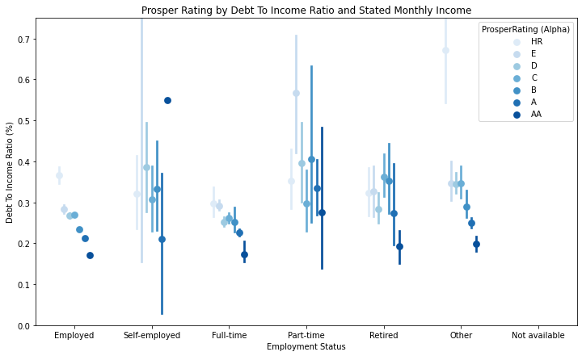